# Analysis of Socioeconomic Mobility in the US - Sophie Ryan

# Introduction

Is the “American Dream” dead? As social and economic mobility in the United States continues to decline, it is important to consider the contributing factors. The “American Dream” offers a promise of the chance for children to do better than their parents. While this may have been a possibility at one point in time, the sentiment of young people today is that the dream is long gone. In Chetty et. al.’s “The fading American dream: Trends in absolute income mobility since 1940” (2017) it is reported that “rates of absolute mobility have fallen from approximately 90% for children born in 1940 to 50% for children born in the 1980s.” As these rates continue to fall and unemployment skyrockets, researching the specific factors that contribute to better opportunities can help raise awareness about inequality and find ways to combat it.

# Abstract

In order to understand the specific elements that create opportunities for improving quality of life in the United States, I chose to explore differences in economic and social factors between parents and children. What makes it easier or harder for people to climb the ladder? With a whole slew of executive orders being passed, including the revocation of Executive Order 11246 which ensured equal employment opportunities for women and minorities, I wanted to explore data that could shed light on this situation. My research will utilize regression models to investigate how the social and economic position of a parent affects that of the child, with respect to gender and race.

# Data

My data will come from the 2022 GSS (General Social Survey). This is a personal interview survey designed to understand social characteristics, behaviors, and attitudes of all adults in the United States. The original data set includes 4,149 observations and 1,185 variables. The variables include a wide range of questions pertaining to demographics, social mobility, educational attainment, employment, family dynamics, religious and political beliefs, and more. I am focused specifically on how race, gender, and their interaction plays into social and economic mobility, so I selected a few variables that I believe will best represent this phenomenon. These variables provide information on the respondent, as well as the respondents’ father and mother. These include educational attainment, occupational prestige, socioeconomic index, and standard of living. I believe these variables will provide valuable insight into social and economic mobility. I plan to compare these factors in male and female respondents for different races to see if there are any discrepancies.

# Exploratory Analysis

## Individual Variables

One limitation of this data is that only 3 race options are included. 1 denotes “white” with 2,641 respondents, 2 denotes “black” with 772 respondents, and 3 denotes “other” with 651 respondents. More valuable insights could be discovered if a wider list of ethnicities were included, however this can still help to uncover a broader pattern.

There are 1,885 males and 2,179 females in this data. Once again, it is limited in that other genders are excluded, however for the purpose of my analysis it will be sufficient.

I will now look at some summary statistics for variables of interest: education, socioeconomic index (SEI), occupational prestige, and standard of living. This can give a preliminary understanding of differences in mean scores for male, female, black, white, and “other” respondents. I will then create models that look at their interactions.

### Education

The education variable ranges from 0 (no formal schooling) to 20 (8 or more years of college).

```
   Min. 1st Qu.  Median    Mean 3rd Qu.    Max.    NA's
   0.00   12.00   14.00   14.17   16.00   20.00      23
```

The mean level of education attained for the entire data set is 14.17, which equates to about 2 years of college.

Respondent's Educational Attainment by Sex

| Sex | Minimum Education Attained | Maximum Education Attained | Mean Education Attained |
| --- | --- | --- | --- |
| Male | 2 | 20 | 14.14949 |
| Female | 0 | 20 | 14.18404 |

Father's Educational Attainment by Sex

| Sex | Minimum Education Attained | Maximum Education Attained | Mean Education Attained |
| --- | --- | --- | --- |
| Male | 0 | 20 | 12.24930 |
| Female | 0 | 20 | 12.43224 |

Mother's Educational Attainment by Sex

| Sex | Minimum Education Attained | Maximum Education Attained | Mean Education Attained |
| --- | --- | --- | --- |
| Male | 0 | 20 | 12.38141 |
| Female | 0 | 20 | 12.38438 |

A first glimpse at the means don’t reveal much difference between genders, however the mean is notably higher for respondents than for their mothers and fathers. On average, respondents completed about 2 years of college and their parents did not complete any college.

Respondent's Educational Attainment by Race

| Race | Minimum Education Attained | Maximum Education Attained | Mean Education Attained |
| --- | --- | --- | --- |
| White | 0 | 20 | 14.27328 |
| Black | 2 | 20 | 13.83833 |
| Other | 1 | 20 | 14.13064 |

Father's Educational Attainment by Race

| Race | Minimum Education Attained | Maximum Education Attained | Mean Education Attained |
| --- | --- | --- | --- |
| White | 0 | 20 | 12.63667 |
| Black | 0 | 20 | 11.46929 |
| Other | 0 | 20 | 11.84400 |

Mother's Educational Attainment by Race

| Race | Minimum Education Attained | Maximum Education Attained | Mean Education Attained |
| --- | --- | --- | --- |
| White | 0 | 20 | 12.63834 |
| Black | 0 | 20 | 12.51156 |
| Other | 0 | 20 | 11.12681 |

Black and “other” race respondents have the lowest mean educational attainment, and once again the parents scored lower than children on the whole. The lowest mean education attained is 11.12 for mothers of race “other”, followed by black and “other” race fathers. This shows that on average, these people did not complete highschool.

#### Education Plots

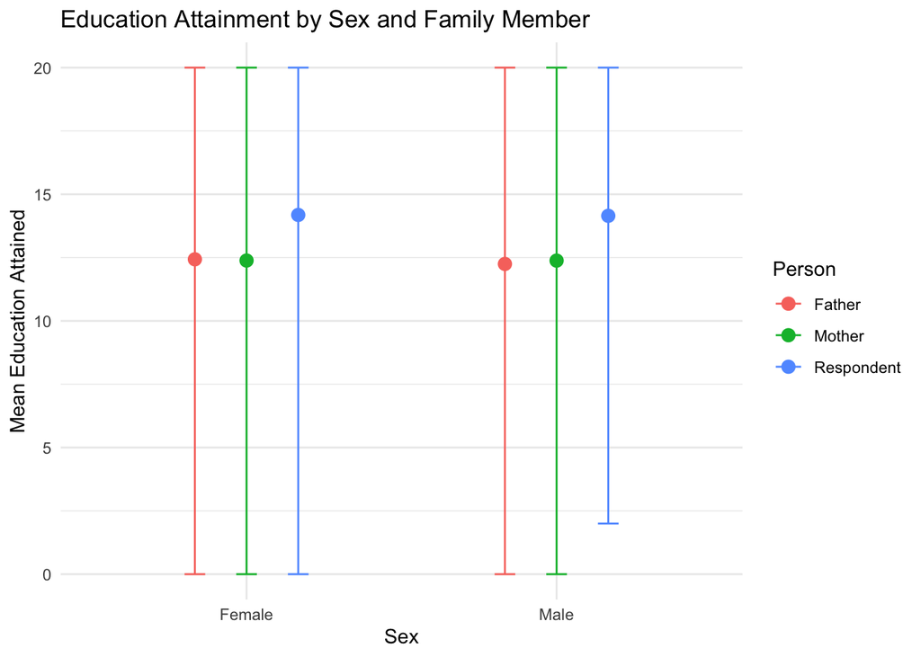

The plot visualizes how respondents average much more schooling than their parents.

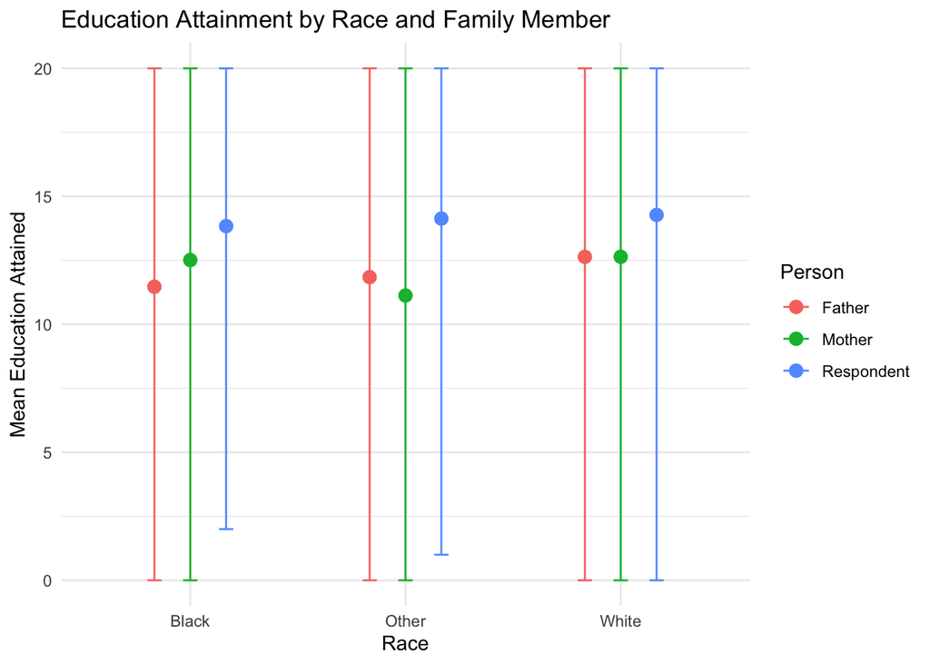

Respondents of all races have completed similar levels of schooling, however white mothers and fathers averaged more than non-white parents.

### Socioeconomic Index (SEI)

Socioeconomic Index scores are used to measure socioeconomic status. They are based on income, education, and occupational ratings. These scores come from the GSS Data Explorer, maintained by NORC at the University of Chicago. The scores in this data range from 10.60 to 92.80, with a mean of 48.69.

```
   Min. 1st Qu.  Median    Mean 3rd Qu.    Max.    NA's
  10.60   26.90   43.00   48.69   68.60   92.80     790
```

Respondent's SEI Score by Sex

| Sex | Minimum SEI Score | Maximum SEI Score | Mean SEI Score |
| --- | --- | --- | --- |
| Male | 10.6 | 92.8 | 48.85301 |
| Female | 10.6 | 92.8 | 48.54425 |

Father's SEI Score by Sex

| Sex | Minimum SEI Score | Maximum SEI Score | Mean SEI Score |
| --- | --- | --- | --- |
| Male | 10.6 | 92.8 | 47.84617 |
| Female | 10.6 | 92.8 | 46.96281 |

Mother's SEI Score by Sex

| Sex | Minimum SEI Score | Maximum SEI Score | Mean SEI Score |
| --- | --- | --- | --- |
| Male | 9.0 | 92.8 | 43.18577 |
| Female | 10.6 | 92.8 | 41.59763 |

There does not appear to be too much variation in SEI between male and female respondents, however the mother’s mean scores are much lower at 43 and 41 versus scores ranging from 46 to 48 for the respondent and the father. The highest mean score comes from male respondents.

Respondent's SEI Score by Race

| Race | Minimum SEI Score | Maximum SEI Score | Mean SEI Score |
| --- | --- | --- | --- |
| White | 10.6 | 92.8 | 50.51549 |
| Black | 10.6 | 92.8 | 41.77287 |
| Other | 10.6 | 92.8 | 46.61596 |

Father's SEI Score by Race

| Race | Minimum SEI Score | Maximum SEI Score | Mean SEI Score |
| --- | --- | --- | --- |
| White | 12.6 | 92.8 | 49.49777 |
| Black | 10.6 | 91.1 | 38.29739 |
| Other | 10.6 | 92.8 | 43.62778 |

Mother's SEI Score by Race

| Race | Minimum SEI Score | Maximum SEI Score | Mean SEI Score |
| --- | --- | --- | --- |
| White | 9.0 | 92.8 | 44.35973 |
| Black | 12.4 | 92.8 | 36.63473 |
| Other | 10.6 | 92.8 | 37.45520 |

Here we begin to see some major discrepancies in mean scores, with a difference of 9 points in mean scores between black and white respondents, and a difference of 11 points in mean scores between black and white fathers. The difference in black and white mother’s scores is less drastic, however the means are much lower overall. The lowest mean score comes from black mothers at 36.6. White people consistently score higher means in all.

#### SEI Plots

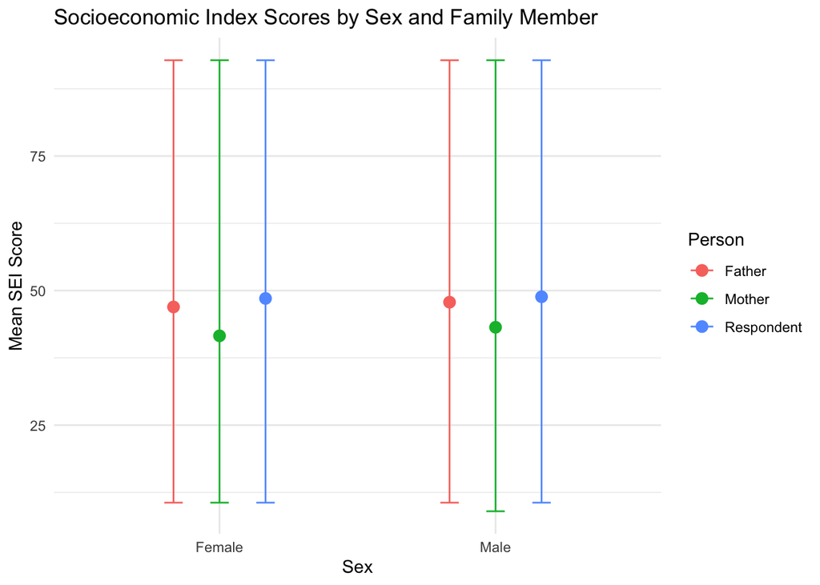

Mothers consistently score lowest on mean SEI, and respondents score highest.

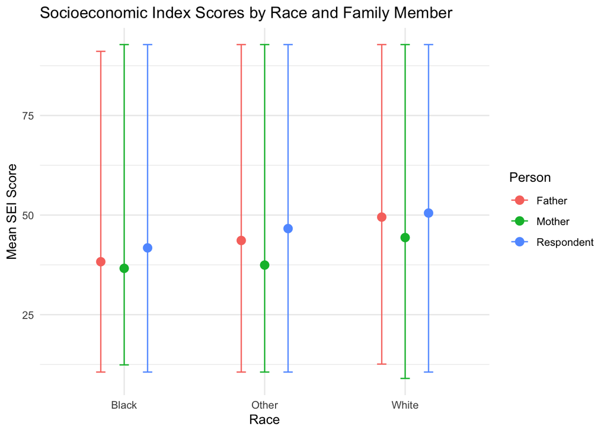

This plot clearly shows how white people score higher overall, and black people have the lowest means. Respondents score higher than their parents for all races.

### Occupational Prestige

Occupational Prestige scores are also a measure created by the NORC. They range from 0 to 100 and reflect perceived importance of occupations based on average ratings of individuals asked to evaluate social standing of various jobs. In this data, the minimum score is 16.00, the mean is 44.97, and the maximum is 80.00.

```
   Min. 1st Qu.  Median    Mean 3rd Qu.    Max.    NA's
  16.00   35.00   45.00   44.97   54.00   80.00     790
```

Respondent's Occupational Prestige Score by Sex

| Sex | Minimum Prestige Score | Maximum Prestige Score | Mean Prestige Score |
| --- | --- | --- | --- |
| Male | 16 | 80 | 44.88464 |
| Female | 16 | 80 | 45.05488 |

Fathers's Occupational Prestige Score by Sex

| Sex | Minimum Prestige Score | Maximum Prestige Score | Mean Prestige Score |
| --- | --- | --- | --- |
| Male | 20 | 80 | 45.07285 |
| Female | 20 | 80 | 44.72281 |

Mother's Occupational Prestige Score by Sex

| Sex | Minimum Prestige Score | Maximum Prestige Score | Mean Prestige Score |
| --- | --- | --- | --- |
| Male | 16 | 80 | 43.56580 |
| Female | 16 | 80 | 42.45111 |

A pattern is beginning to emerge here, where the mother’s score are consistently lower than the father and respondents of either gender.

Respondent's Occupational Prestige Score by Race

| Race | Minimum Prestige Score | Maximum Prestige Score | Mean Prestige Score |
| --- | --- | --- | --- |
| White | 16 | 80 | 45.86944 |
| Black | 17 | 80 | 42.03488 |
| Other | 16 | 80 | 43.34043 |

Father's Occupational Prestige Score by Race

| Race | Minimum Prestige Score | Maximum Prestige Score | Mean Prestige Score |
| --- | --- | --- | --- |
| White | 21 | 80 | 45.88641 |
| Black | 20 | 74 | 40.83188 |
| Other | 20 | 80 | 42.87654 |

Mother's Occupational Prestige Score by Race

| Race | Minimum Prestige Score | Maximum Prestige Score | Mean Prestige Score |
| --- | --- | --- | --- |
| White | 16 | 80 | 43.82383 |
| Black | 16 | 80 | 40.86713 |
| Other | 16 | 80 | 40.33200 |

Mean Occupational Prestige scores are higher on the whole for white people, particularly for the respondent and father. They are lowest for black fathers, as well as black and “other” race mothers. Black fathers also have the lowest maximum score at 74.

#### Prestige Plots

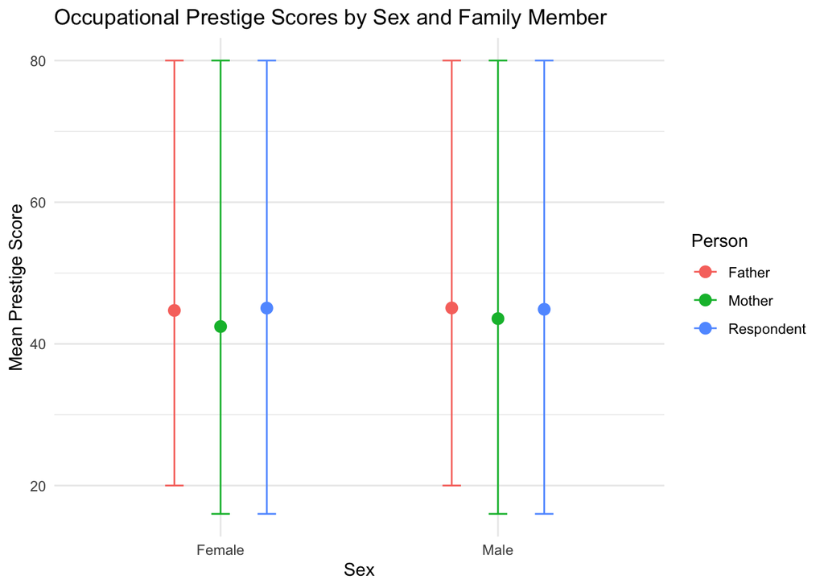

These scores are slightly more consistent, however mothers still score the lowest.

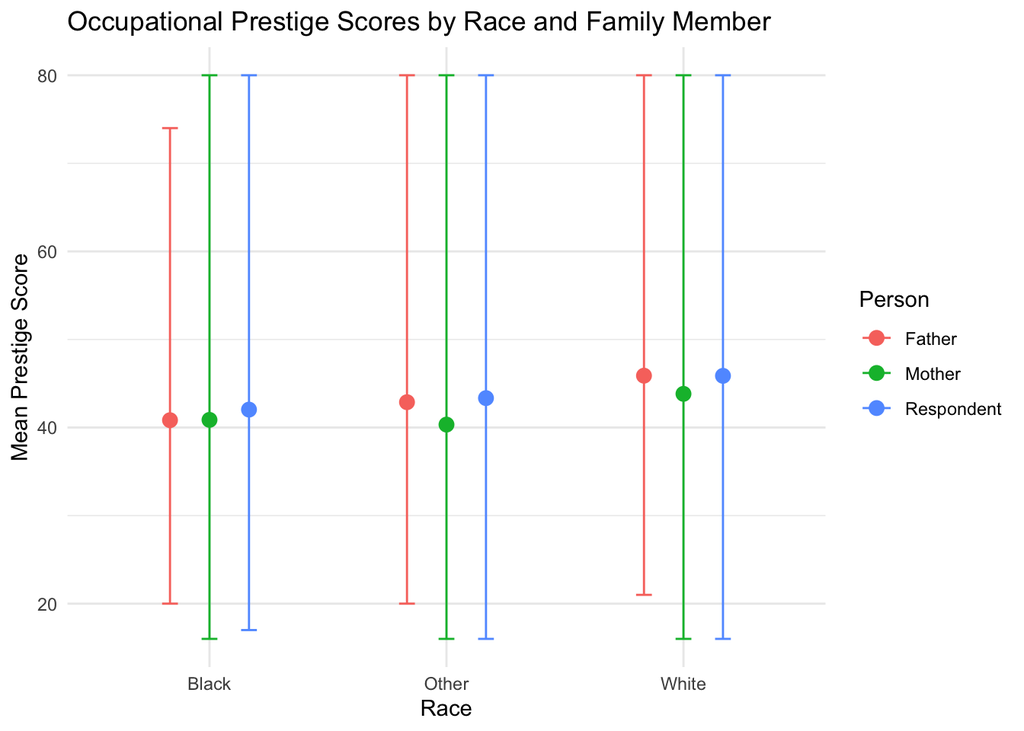

White people show higher mean prestige scores overall. There is a smaller difference between black mothers and fathers than that of other races, but the means are lower.

### Standard of Living

Two ordinal variables in this data, “parsol” and “kidssol” estimate standard of living of the respondent compared to their parents, and standard of living of the respondents’ child compared to them. It ranges from 1 (“much better”) to 5 (“much worse”).

```
   Min. 1st Qu.  Median    Mean 3rd Qu.    Max.    NA's
  1.000   1.000   2.000   2.364   3.000   5.000      24
```

```
   Min. 1st Qu.  Median    Mean 3rd Qu.    Max.
  1.000   1.000   2.000   2.401   3.000   5.000
```

Parent Standard of Living Score by Sex

| Sex | Minimum SOL Score | Maximum SOL Score | Mean SOL Score |
| --- | --- | --- | --- |
| Male | 1 | 5 | 2.373333 |
| Female | 1 | 5 | 2.357009 |

Respondent's Child Standard of Living Score by Sex

| Sex | Minimum SOL Score | Maximum SOL Score | Mean SOL Score |
| --- | --- | --- | --- |
| Male | 1 | 5 | 2.445415 |
| Female | 1 | 5 | 2.364791 |

Parent Standard of Living Score by Race

| Race | Minimum SOL Score | Maximum SOL Score | Mean SOL Score |
| --- | --- | --- | --- |
| White | 1 | 5 | 2.452888 |
| Black | 1 | 5 | 2.212435 |
| Other | 1 | 5 | 2.149254 |

Respondent's Child Standard of Living Score by Race

| Race | Minimum SOL Score | Maximum SOL Score | Mean SOL Score |
| --- | --- | --- | --- |
| White | 1 | 5 | 2.574815 |
| Black | 1 | 5 | 2.040816 |
| Other | 1 | 5 | 2.065217 |

The highest mean score is 2.57 for white children of respondents, indicating a perceived worse standard of living, and the lowest (best) mean is 2.04 for respondents black children.

#### SOL Plots

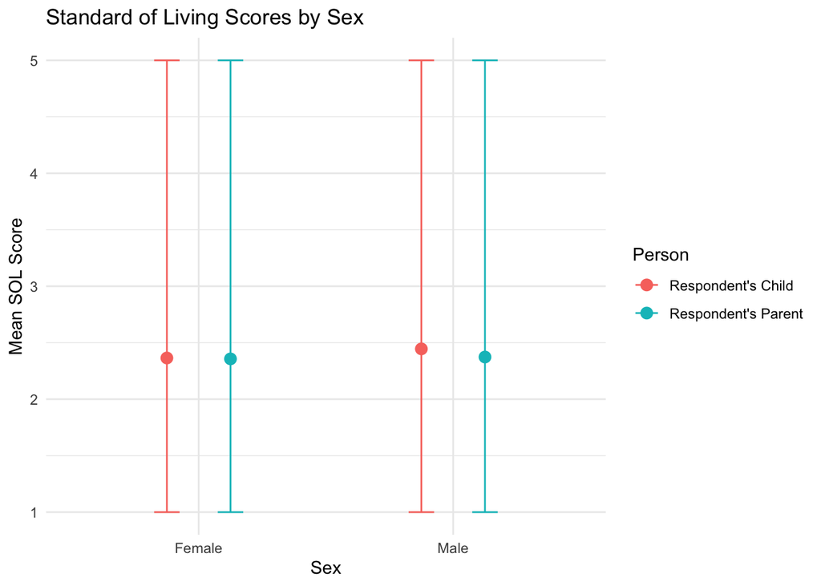

The plot shows how the best standard of living scores are for children of female respondents.

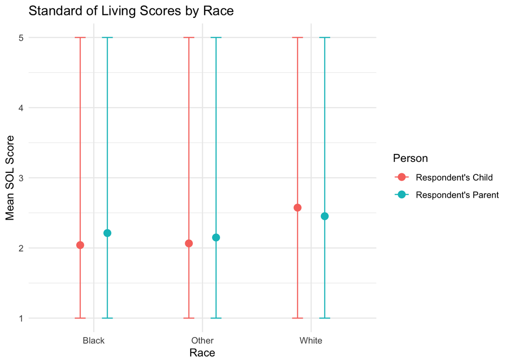

I think it’s very interesting that white respondents report worse standards of living, for both themselves and their children, despite performing better on previous metrics. It’s important to note how this is personal perception, which is why it’s necessary to consider other measures.

# Results

## DAG’s

DAGs (Directed Acyclic Graphs) give an idea of causal relationships between variables. I’ve created some DAGs based on what I observed in exploratory analysis and my assumptions about the data.

```
Plot coordinates for graph not supplied! Generating coordinates, see ?coordinates for how to set your own.
```

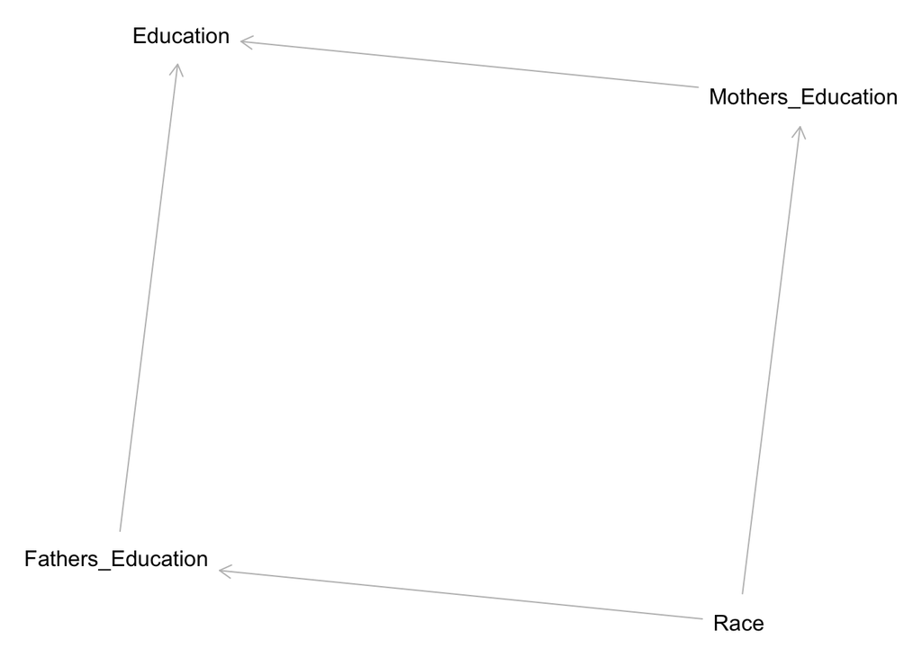

```
Plot coordinates for graph not supplied! Generating coordinates, see ?coordinates for how to set your own.
```

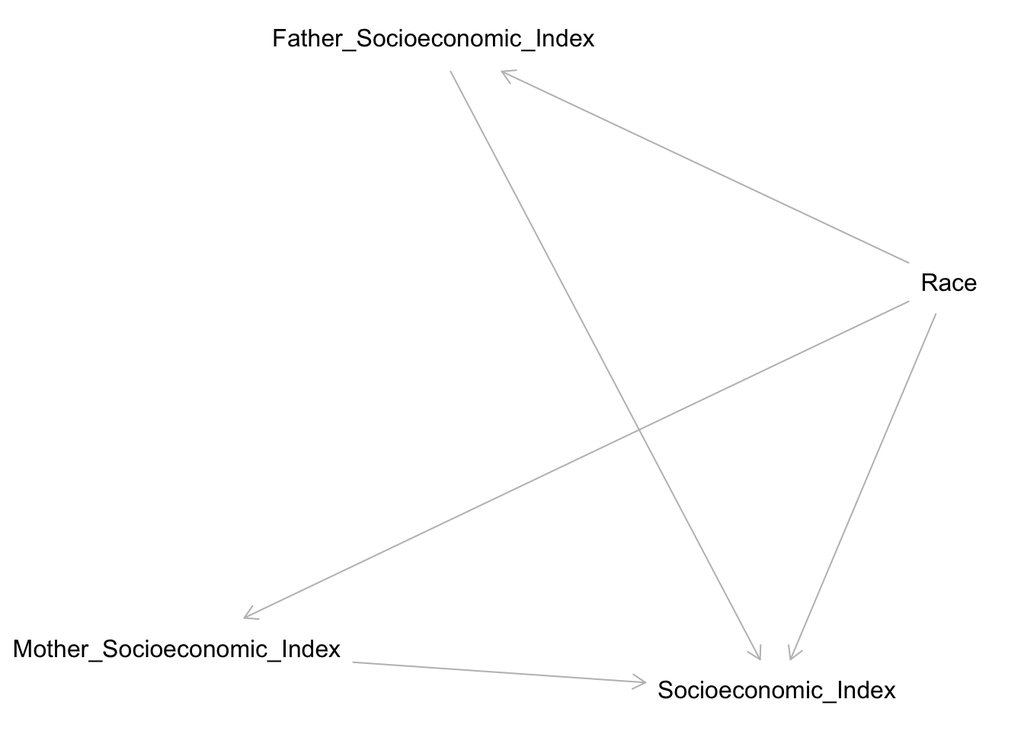

```
Plot coordinates for graph not supplied! Generating coordinates, see ?coordinates for how to set your own.
```

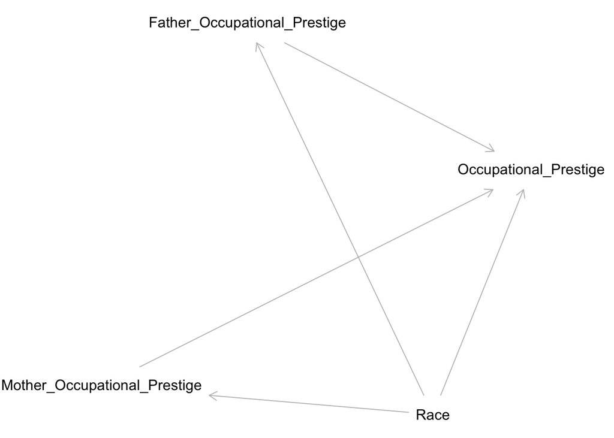

```
Plot coordinates for graph not supplied! Generating coordinates, see ?coordinates for how to set your own.
```

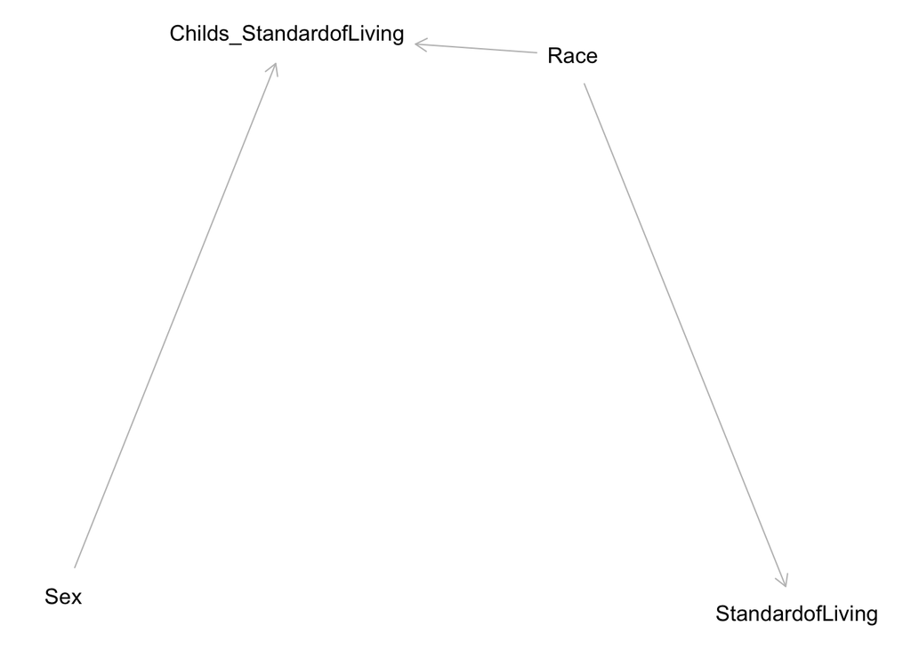

These plots model how I predict the variables to influence each other.

## Regression Models

I’ve created regression models for each variable that I’ve analyzed. I’ve included one model that shows main effects, and another that shows interaction effects for each variable. The main effect models assume independent, additive effects on the outcome variable, while the interaction models test combined effects of variables, and display how the outcome variable differs between males and females, and black/white/other races.

### Education

Education Regression Models

|  | &nbsp;Race Interaction | Race Main Effects | &nbsp;Sex Interaction | Sex Main Effects |
| --- | --- | --- | --- | --- |
| Intercept | 8.317*** | 8.977*** | 8.847*** | 9.057*** |
|  | (1.235) | (0.464) | (0.758) | (0.365) |
| Race | −0.190 | 0.034 |  |  |
|  | (0.563) | (0.154) |  |  |
| Sex (Female) |  |  | −1.586 | −0.021 |
|  |  |  | (1.099) | (0.211) |
| Mother's Education | 0.245+ | 0.193*** | 0.270*** | 0.191*** |
|  | (0.129) | (0.036) | (0.079) | (0.036) |
| Father's Education | 0.154 | 0.216*** | 0.266** | 0.216*** |
|  | (0.131) | (0.034) | (0.088) | (0.034) |
| Race x Mother's Edu | 0.044 |  |  |  |
|  | (0.071) |  |  |  |
| Race x Father's Edu | 0.107+ |  |  |  |
|  | (0.065) |  |  |  |
| Mother x Father Edu | 0.005 |  | −0.009 |  |
|  | (0.010) |  | (0.007) |  |
| Race x Ma x Pa Edu | −0.011* |  |  |  |
|  | (0.005) |  |  |  |
| Sex x Mother's Edu |  |  | 0.050 |  |
|  |  |  | (0.113) |  |
| Sex x Father's Edu |  |  | 0.130 |  |
|  |  |  | (0.121) |  |
| Sex x Ma x Pa Edu |  |  | −0.004 |  |
|  |  |  | (0.009) |  |
| Num.Obs. | 675 | 675 | 675 | 675 |
| R2 | 0.257 | 0.243 | 0.253 | 0.243 |
| R2 Adj. | 0.249 | 0.240 | 0.245 | 0.240 |
| AIC | 3276.0 | 3280.4 | 3279.5 | 3280.5 |
| BIC | 3316.6 | 3303.0 | 3320.1 | 3303.0 |
| Log.Lik. | −1629.005 | −1635.214 | −1630.732 | −1635.234 |
| RMSE | 2.70 | 2.73 | 2.71 | 2.73 |

+ p < 0.1, * p < 0.05, ** p < 0.01, *** p < 0.001

The results of the regression show that the mother and fathers education is a significant indicator of the the child’s education, in both the main effects and interaction models for sex and the main effect model for race. The sex interaction model indicates that for every one year increase in the mother and fathers education, the child’s education increases by 0.270 years and 0.266 years, respectively. In the race main effect model, for every one year increase in the fathers education, the education of the child increases by 0.216 years. For every one year increase in the mother’s education, the child’s education increases by 0.193 years, indicating a slightly weaker effect than the father. The 3-way interaction between race, mothers education, and fathers education is significant at the 0.05 alpha level. The coefficient is negative, meaning the effect of parental education is weaker for non-white people.

The adjusted R^2 and R^2 values for all models are similar, with values around 0.24-0.25. This indicates that ~24% of the variance in the outcome is explained by the predictors.

### Socioeconomic Index

SEI Regression Models

|  | &nbsp;Race Interaction | Race Main Effects | &nbsp;Sex Interaction | Sex Main Effects |
| --- | --- | --- | --- | --- |
| Intercept | 47.631*** | 33.010*** | 35.267*** | 27.767*** |
|  | (10.966) | (3.599) | (6.876) | (2.716) |
| Race | −6.829 | −1.485 |  |  |
|  | (6.767) | (1.456) |  |  |
| Sex (Female) |  |  | 1.167 | 4.644* |
|  |  |  | (9.526) | (1.905) |
| Mother's SEI | −0.220 | 0.164*** | 0.010 | 0.171*** |
|  | (0.261) | (0.046) | (0.159) | (0.045) |
| Father's SEI | −0.097 | 0.207*** | −0.007 | 0.215*** |
|  | (0.248) | (0.050) | (0.149) | (0.049) |
| Race x Mother's SEI | 0.152 |  |  |  |
|  | (0.171) |  |  |  |
| Race x Father's SEI | 0.103 |  |  |  |
|  | (0.169) |  |  |  |
| Mother x Father SEI | 0.007 |  | 0.005 |  |
|  | (0.005) |  | (0.003) |  |
| Race x Ma x Pa SEI | −0.003 |  |  |  |
|  | (0.004) |  |  |  |
| Sex x Mother's SEI |  |  | 0.024 |  |
|  |  |  | (0.221) |  |
| Sex x Father's SEI |  |  | 0.179 |  |
|  |  |  | (0.212) |  |
| Sex x Ma x Pa SEI |  |  | −0.003 |  |
|  |  |  | (0.004) |  |
| Num.Obs. | 526 | 526 | 526 | 526 |
| R2 | 0.099 | 0.092 | 0.108 | 0.101 |
| R2 Adj. | 0.087 | 0.087 | 0.096 | 0.096 |
| AIC | 4748.6 | 4744.4 | 4743.4 | 4739.5 |
| BIC | 4787.0 | 4765.7 | 4781.8 | 4760.8 |
| Log.Lik. | −2365.321 | −2367.203 | −2362.704 | −2364.749 |
| RMSE | 21.71 | 21.79 | 21.60 | 21.69 |

+ p < 0.1, * p < 0.05, ** p < 0.01, *** p < 0.001

At the 0.001 significance level, the mother and father’s SEI scores show significant positive effects in both main effect models, meaning higher parental SEI is strongly associated with higher respondent SEI. Sex is significant at the 0.05 alpha level, suggesting females score better holding all other variables constant.

The adjusted R^2 and R2 are around 0.09 for the race models, and 0.1 for the sex models. This suggests that 9%-10% of the variance in the outcome is explained by the predictors. Additionally, adjusted R2 is the same for the interaction and main effect models, which shows they are performing equally well.

### Occupational Prestige

Occupational Prestige Regression Models

|  | &nbsp;Race Interaction | Race Main Effects | &nbsp;Sex Interaction | Sex Main Effects |
| --- | --- | --- | --- | --- |
| Intercept | 59.527*** | 33.854*** | 45.442*** | 30.767*** |
|  | (15.432) | (2.880) | (9.545) | (2.481) |
| Race | −7.119 | −0.841 |  |  |
|  | (9.692) | (0.842) |  |  |
| Sex (Female) |  |  | 1.899 | 2.930** |
|  |  |  | (13.945) | (1.117) |
| Mother's Pres | −0.540 | 0.154*** | −0.129 | 0.158*** |
|  | (0.351) | (0.044) | (0.225) | (0.044) |
| Father's Pres | −0.431 | 0.115** | −0.240 | 0.119** |
|  | (0.343) | (0.044) | (0.212) | (0.043) |
| Race x Mother's Pres | 0.219 |  |  |  |
|  | (0.221) |  |  |  |
| Race x Father's Pres | 0.115 |  |  |  |
|  | (0.222) |  |  |  |
| Mother x Father Pres | 0.015* |  | 0.007 |  |
|  | (0.007) |  | (0.005) |  |
| Race x Ma x Pa Pres | −0.004 |  |  |  |
|  | (0.005) |  |  |  |
| Sex x Mother's Pres |  |  | −0.085 |  |
|  |  |  | (0.317) |  |
| Sex x Father's Pres |  |  | 0.078 |  |
|  |  |  | (0.313) |  |
| Sex x Ma x Pa Pres |  |  | 0.001 |  |
|  |  |  | (0.007) |  |
| Num.Obs. | 526 | 526 | 526 | 526 |
| R2 | 0.066 | 0.050 | 0.073 | 0.061 |
| R2 Adj. | 0.053 | 0.045 | 0.061 | 0.055 |
| AIC | 4183.5 | 4184.2 | 4179.2 | 4178.3 |
| BIC | 4221.9 | 4205.5 | 4217.6 | 4199.6 |
| Log.Lik. | −2082.739 | −2087.097 | −2080.593 | −2084.157 |
| RMSE | 12.69 | 12.79 | 12.64 | 12.72 |

+ p < 0.1, * p < 0.05, ** p < 0.01, *** p < 0.001

The output of the Occupational Prestige model shows that the prestige scores of the mother and father are significant at the 0.01 alpha level in the main effect models for both race and sex. Sex is significant at the 0.01 alpha level for the main effects model. The coefficients are positive, indicating that being female offers an advantage in this case, but less so when interaction terms are included.

Adjusted R^2 values are around 0.05 for the race models, and around 0.06 for the sex models, indicating 5%-6% of variance in the outcome is explained by the predictors. The adjusted R^2 is higher for the interaction models, indicating they may be performing better than the main effect models.

### Standard of Living

Standard of Living Regression Models

|  | &nbsp;Race Interaction | Race Main Effects | &nbsp;Sex Interaction | Sex Main Effects |
| --- | --- | --- | --- | --- |
| Intercept | 2.330*** | 2.195*** | 1.806*** | 1.812*** |
|  | (0.193) | (0.120) | (0.127) | (0.095) |
| Race | −0.355** | −0.266*** |  |  |
|  | (0.113) | (0.053) |  |  |
| Sex (Female) |  |  | −0.073 | −0.085 |
|  |  |  | (0.171) | (0.077) |
| Respondent's SOL | 0.196** | 0.255*** | 0.274*** | 0.271*** |
|  | (0.073) | (0.032) | (0.048) | (0.032) |
| Race x Parent SOL | 0.040 |  |  |  |
|  | (0.044) |  |  |  |
| Sex x Parent SOL |  |  | −0.005 |  |
|  |  |  | (0.065) |  |
| Num.Obs. | 985 | 985 | 985 | 985 |
| R2 | 0.092 | 0.091 | 0.069 | 0.068 |
| R2 Adj. | 0.089 | 0.089 | 0.066 | 0.067 |
| AIC | 3147.0 | 3145.8 | 3171.6 | 3169.6 |
| BIC | 3171.4 | 3165.3 | 3196.1 | 3189.2 |
| Log.Lik. | −1568.479 | −1568.881 | −1580.801 | −1580.803 |
| F | 32.940 | 49.019 | 24.047 | 36.104 |
| RMSE | 1.19 | 1.19 | 1.20 | 1.20 |

+ p < 0.1, * p < 0.05, ** p < 0.01, *** p < 0.001

In this model, we see that race is a strong indicator of a child’s standard of living for both the main effects model and interaction model. It shows a significant negative effect at the 0.01 alpha level, indicating scores will be lower for non-white people. Note that in this case a “lower” score is actually better. The standard of living score of the respondent is also significant at the 0.01 alpha level for all models. This means that as the SOL score of the respondent increases, the child’s SOL will also increase.

## Plots

I’ve created 4 plots to help visualize the models. The first two plots show education, occupational prestige, and SEI based on gender, and the final two show outcomes based on race. The plots include confidence intervals.

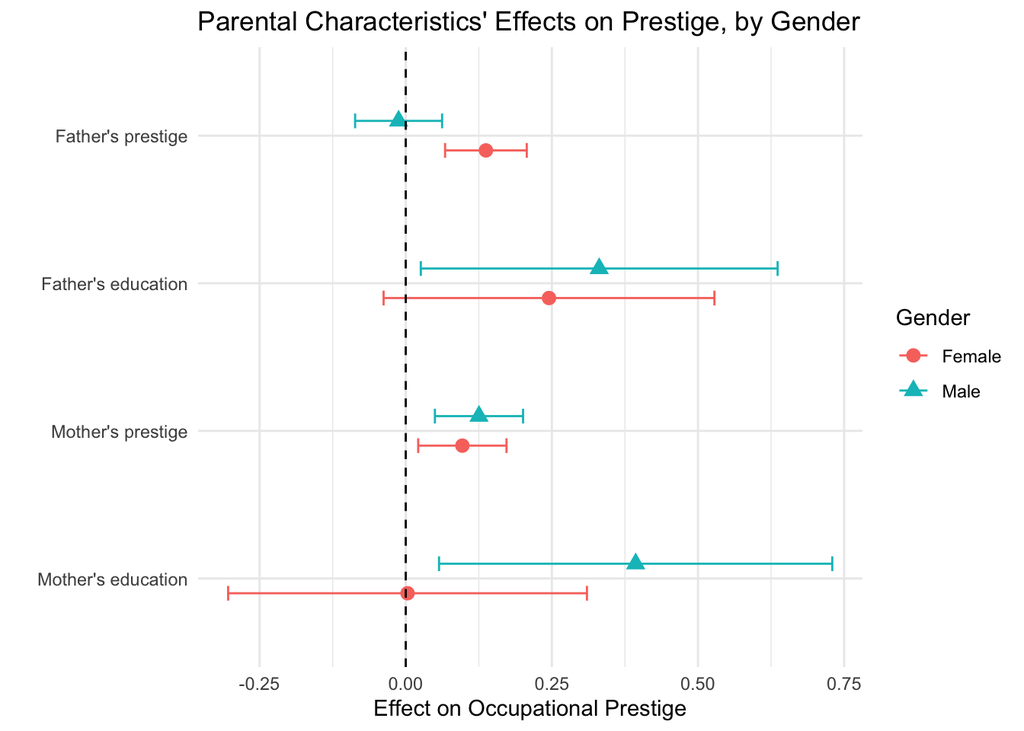

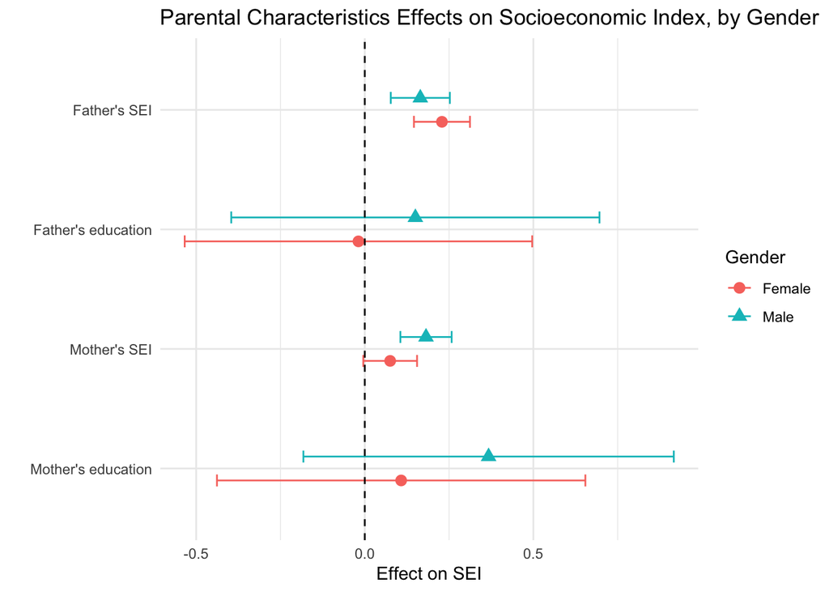

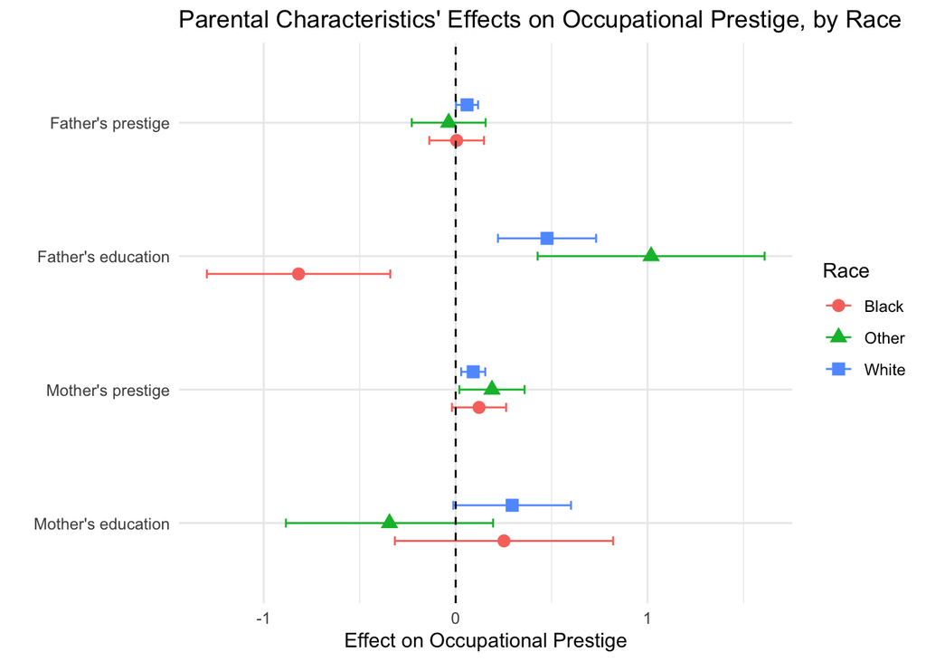

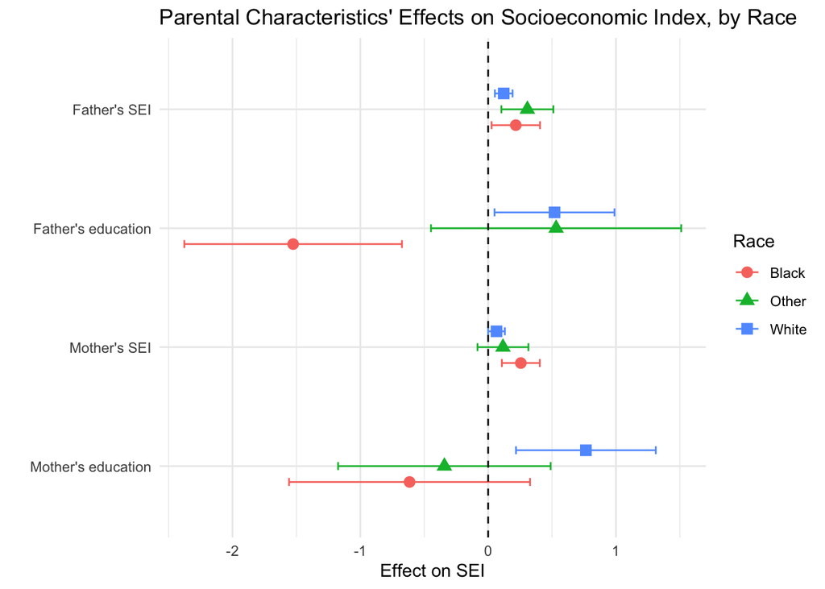